# New/modified functions for my R analyses

2018-08-03

This is a project used to keep the development of new functions (and the modification/adaptation of existing ones) organized and clear, and separate from the actual analyses of my PhD data.  
Necessary because the process involves a lot of testing and tweaking, especially for complicated multivariate analyses - I’d like to keep a record of my reasoning.  
Then I’ll copy the finished functions to the results analysis directory and apply them to my own data.

Setup.

Define the working subdirectories.

```r
## print the working directory, just to be on the safe side
paste("You are here: ", getwd())

data.dir <- "data"    # input data files
functions.dir <- "R"  # functions & scripts
save.dir <- "output"  # clean data, output from models & more complex calculations
figures.dir <- "figs" # plots & figures
```

Import the necessary libraries.

```r
library(here) ## easily find project root directory and construct relative file paths
library(vegan) ## community ecology uni- and multivariate analyses
library(tidyverse) ## data cleaning, manipulation and analysis
```

## SIMPER - within-group similarity

The vegan package already contains a SIMPER function, but it only calculates **between-group** (dis)similarity. I also want to check out the within-group similarity (= which species contribute the most to the definition of the group according to SIMPER).  
As a starting point, I’m using the vegan code for the between-group SIMPER. I’m modifying it according to the original article by Clarke (1993): Non-parametric multivariate analyses of changes in community structure. Australian Journal of Ecology 18, 117–143. https://doi.org/10.1111/j.1442-9993.1993.tb00438.x  
In the article there is a formula and procedure for calculating the group similarity and the individual species’ contributions to it, although it’s possibly too complicated.  
The **example dataset** I’m using is the same one from the journal article - the **Exe nematodes**. It’s also included in PRIMER installations as an example dataset. However, in the article there were 179 nematode species, while in the dataset I’ve got there are 140 - I’m not expecting a perfect match in the numbers.  
To deal with this, I used PRIMER to do a quick SIMPER on the 140-species dataset, both with groups obtained from a de novo MDS and with the pre-defined groups from the article.  
Another complication is the fact that some groups only have 1 or 2 samples - so no meaningful similarity can be calculated, but let’s ignore that for now..  
The vegan between-group SIMPER also calculates permutations to estimate p-values for the species contributions - to begin I’m not going to implement them, because I don’t fully understand the code (it’s poorly documented and has matrix calculations in loops that confuse me). So these are the big chunks of commented-out code in the function.

#### Preliminary testing

I’ve already come some way towards modifying the function to suit me - I’m going to import and test it on the data, see if it works..

```r
source(here(functions.dir, "simper_within_group_2.R"))
```

Import the nematode data.

```r
## import as is, although I would have preferred no row names and such
exe.abnd <- read.csv(file = here(data.dir, "exe_nematode_abnd.csv"), header = TRUE, row.names = 1)

## this needs to be transposed - species in columns and sites in rows, as per vegan requirements. I'm going to leave it as a matrix, to make my life easier later on.
exe.abnd <- t(exe.abnd)
exe.abnd[1:4, 1:10] ## only check out a subset; otherwise printout takes up enormous amounts of space
```

Define the groups - first, the original-article groups..

```r
(exe.groups <- as.character(c(rep(1, 4), 3, 2, rep(10, 3), 3, 2, rep(4, 8))))
```

Cool.. After many, MANY trial and error and line-by-line tweaks and stuff (undocumented here)… Let’s test the final version of the function on the data!

```r
exe.simper.within <- simper_within_group(exe.abnd, exe.groups)

exe.simper.within[[1]]
exe.simper.within[[5]]
attr(exe.simper.within, "overall.group.similarity")
```

[output not shown]

Note: the average abundances won’t be the same as with SIMPER from PRIMER (stored in output folder for comparison), because it accepts as input the double-square root transformed abundance matrix and gets the output average abundances from it again in the end. I intentionally made my functon receive as input an UNTRANSFORMED abundance matrix, so that the average abundances in the output can be the actual average counts, which is much more informative and intuitive.

The output as a list with overall group similarities is a bit awkward. Unlike the vegan simper function (for between-group similarity breakdowns), mine doesn’t have a specific class for its output, and no clean pretty summary method, either.  
There is also no p-value - I didn’t implement the permutations, because this is math way, way over my head.  
Because my function uses a ton of for loops and/or apply functions for its internal calculations, if ever it is applied on a larger dataset the computer will probably choke.  
In any case, the within-group SIMPER now works and gives passable results; I only intend to use it once, for demonstration and comparison with the other (non-distance-based) community analysis methods in my thesis.

## MDS - plot ordination in ggplot

Perform MDS on the Exe nematode data.

```r
(exe.mds <- metaMDS(exe.abnd))
```

```
Square root transformation
Wisconsin double standardization
*** Solution reached

Call:
metaMDS(comm = exe.abnd)

global Multidimensional Scaling using monoMDS

Data:     wisconsin(sqrt(exe.abnd))
Distance: bray

Dimensions: 2
Stress:     0.06594816
Stress type 1, weak ties
Two convergent solutions found after 20 tries
Scaling: centring, PC rotation, halfchange scaling
Species: expanded scores based on ‘wisconsin(sqrt(exe.abnd))’
```

First, source the MDS-envfit custom functions..

```r
source(here(functions.dir, "plot_mds_revised.R"))
```

Try extracting and plotting the MDS scores..

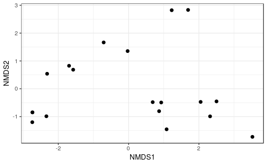

```r
## first try: no groups, just plot
plot_mds(exe.mds) +
    theme_bw()
```

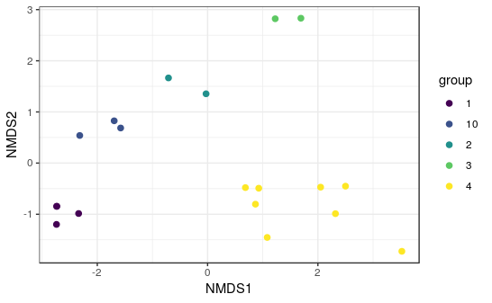

```r
## second try: color points by group
plot.exe.mds <- plot_mds(exe.mds, groups = exe.groups)
plot.exe.mds +
    scale_color_viridis_d() +
    theme_bw()
```

All right, it works now. No need to hard-code colour scales and other ggplot settings in the fucntion - can be added later directly to the plot, as above.

## Envfit - fit environmental parameters to ordination & plot in ggplot

Import environmental data for the nematode dataset (yes, there is one).

```r
(exe.env.data <- read_csv(here(data.dir, "exe_environment.csv"))
)
```

| station | med_part_diam | depth_water_tab | depth_H2S_layer | shore_height | %organics | interstit_salinity |
| --- | --- | --- | --- | --- | --- | --- |
| 1 | 0.060 | 0.000 | 2.167 | 4 | 6.43 | 24.833 |
| 2 | 0.060 | 0.000 | 3.183 | 3 | 7.06 | 22.833 |
| 3 | 0.060 | 0.000 | 1.817 | 2 | 7.99 | 17.833 |
| 4 | 0.060 | 0.000 | 2.020 | 1 | 7.15 | 16.200 |
| 5 | 1.275 | 20.000 | 20.000 | 5 | 0.24 | 10.000 |
| 6 | 0.562 | 3.417 | 2.950 | 4 | 0.37 | 76.600 |
| 7 | 0.060 | 0.000 | 2.167 | 3 | 1.98 | 76.000 |
| 8 | 0.177 | 0.000 | 2.683 | 2 | 2.22 | 81.200 |
| 9 | 0.060 | 0.000 | 2.660 | 1 | 5.88 | 71.200 |
| 10 | 0.451 | 20.000 | 20.000 | 5 | 0.09 | 10.000 |

[output cut: 9 more lines]

Run envfit, using this data..

```r
exe.envfit <- envfit(exe.mds,
                     exe.env.data %>% select(-station))
exe.envfit
```

```
***VECTORS

                      NMDS1    NMDS2     r2 Pr(>r)
med_part_diam       0.93145  0.36386 0.6419  0.001 ***
depth_water_tab     0.75192  0.65925 0.4775  0.008 **
depth_H2S_layer     0.99525 -0.09732 0.8464  0.001 ***
shore_height        0.45644  0.88976 0.3722  0.023 *
%organics          -0.90751 -0.42003 0.8051  0.001 ***
interstit_salinity  0.75139 -0.65985 0.3126  0.059 .
---
Signif. codes:  0 ‘***’ 0.001 ‘**’ 0.01 ‘*’ 0.05 ‘.’ 0.1 ‘ ’ 1
Permutation: free
Number of permutations: 999
```

Once upon a time, I must have found a custom function for correcting the p-values which might be biased due to the very large number of permutations performed by envfit. By default, it applies a Bonferroni correction for multiple testing.  
Let’s try it out now..

```r
source(here(functions.dir, "p_adjust_envfit.R"))
```

Apply the p-value adjustment/correction..

```r
(exe.envfit.adj <- p_adjust_envfit(exe.envfit)
)
```

```
***VECTORS

                      NMDS1    NMDS2     r2 Pr(>r)
med_part_diam       0.93145  0.36386 0.6419  0.006 **
depth_water_tab     0.75192  0.65925 0.4775  0.048 *
depth_H2S_layer     0.99525 -0.09732 0.8464  0.006 **
shore_height        0.45644  0.88976 0.3722  0.138
%organics          -0.90751 -0.42003 0.8051  0.006 **
interstit_salinity  0.75139 -0.65985 0.3126  0.354
---
Signif. codes:  0 ‘***’ 0.001 ‘**’ 0.01 ‘*’ 0.05 ‘.’ 0.1 ‘ ’ 1
Permutation: free
Number of permutations: 999
```

Well, all right then. Let’s proceed. Now let’s play in ggplot again..

```r
## extract the envfit scores - easier format for plotting in ggplot..
(exe.envfit.scrs <- extract_envfit_scores(exe.envfit.adj, pval = 0.05)
)
```

| param | NMDS1 | NMDS2 | p |
| --- | --- | --- | --- |
| med_part_diam | 0.9314527 | 0.36386235 | 0.006 |
| depth_water_tab | 0.7519238 | 0.65925001 | 0.048 |
| depth_H2S_layer | 0.9952534 | -0.09731747 | 0.006 |
| %organics | -0.9075095 | -0.42003154 | 0.006 |

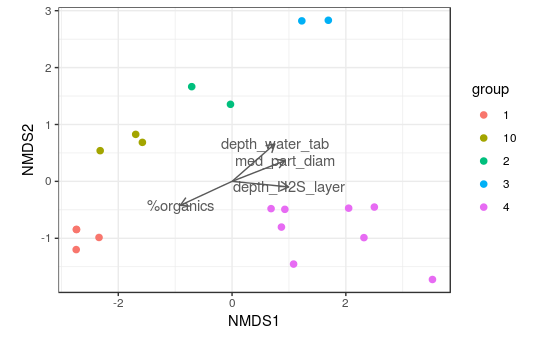

```r
## plot over the ordination
plot.exe.envfit <- plot_envfit(plot.exe.mds,
                               exe.envfit.scrs,
                               param.labels = param,
                               label.col = "grey35")
plot.exe.envfit +
    theme_bw()
```

OK, that should do it..

## Ordisurf - fit & plot environmental parameters not as vectors, but as surfaces

When I first started digging and playing with this, I made two variations of the plotting function: one using base R plot, and the other - ggplot. In ggplot, it was diffiuclt to label the isolines prettily, so eventually I gave up.  
Let’s give it another try now, at the same time cleaning and streamlining as usual.  
Import ordisurf-related custom functions.

```r
source(here(functions.dir, "plot_ordisurf.R"))
```

First, perform ordisurf for the ordination of the Exe nematodes and using the same environmental data - but only for the most significant envfit variables (it’s a function in vegan).

```
Family: gaussian
Link function: identity

Formula:
y ~ s(x1, x2, k = 10, bs = "tp", fx = FALSE)

Estimated degrees of freedom:
8.45  total = 9.45

REML score: 41.30715
```

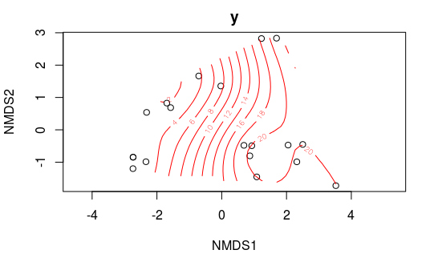

```r
## ordisurf works only on a single variable at a time, so for testing I'm going to use the variable depth of the H2S layer
(ordi.h2s <- ordisurf(exe.mds ~ exe.env.data %>% pull(depth_H2S_layer))
)
```

This is the base plot, which can and will be improved.  
Let’s try plotting in ggplot.

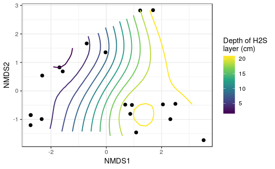

If the MDS points are coloured - by station or other group - ggplot throws an error, because you can’t have different colour aesthetics for two different geoms (point and contour here).

…Aaaand here’s why I ended up using base R graphics: I can’t find a way to label the contours that I like. I tried using package directlabels; however, I can’t round the values to obtain a sensible label..

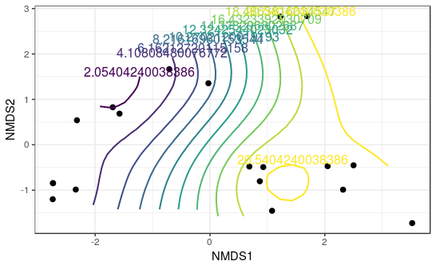

```r
directlabels::direct.label(plot.exe.ordi.h2s, method = "top.pieces")
```

So, in base grahics..

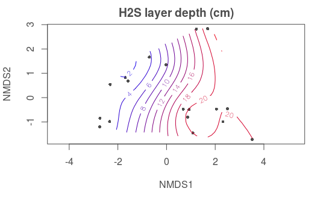

```r
plot_mds_ordisurf(exe.mds, ordi.h2s)
title(main = "H2S layer depth (cm)", col.main = "grey30")
```

Well, I think this is as good as it gets..  
Let’s see how it does in a loop, for ALL the selected environmental variables (p < 0.05).

```r
## get the environmental data we want (significant variables from envfit, p < 0.05)
(exe.env.data.ordi <- exe.env.data %>%
     select(exe.envfit.scrs %>% pull(param))
)
```

| med_part_diam | depth_water_tab | depth_H2S_layer | %organics |
| --- | --- | --- | --- |
| 0.060 | 0.000 | 2.167 | 6.43 |
| 0.060 | 0.000 | 3.183 | 7.06 |
| 0.060 | 0.000 | 1.817 | 7.99 |
| 0.060 | 0.000 | 2.020 | 7.15 |
| 1.275 | 20.000 | 20.000 | 0.24 |
| 0.562 | 3.417 | 2.950 | 0.37 |
| 0.060 | 0.000 | 2.167 | 1.98 |
| 0.177 | 0.000 | 2.683 | 2.22 |
| 0.060 | 0.000 | 2.660 | 5.88 |
| 0.451 | 20.000 | 20.000 | 0.09 |

[output cut: 9 more lines]

```r
mapply(function(x, y) {
    ## construct the file name
    plot.name <- paste0(x, ".png")

    ## open png graphical device - we're working with base graphics
    png(here(figures.dir, plot.name), width = 1000, height = 1000, res = 200)

    ## plot ordisurf using my pretty custom function
    plot_mds_ordisurf(exe.mds, y)

    ## add a title
    title(main = x, col.main = "grey30", cex.main = 0.9)

    ## close the graphics device
    dev.off()
},
names(ordi.list.all),
ordi.list.all,
SIMPLIFY = FALSE)
```

```
$med_part_diam
null device
          1

$depth_water_tab
null device
          1

$depth_H2S_layer
null device
          1

$`%organics`
null device
          1
```

The png device (and all other image formats, for that matter - though I haven’t tried pdf) doesn’t like to write files in a loop. Specifically, it yells if the image size and resolution are not to its liking.. sometimes the figure margins are too big for it, sometimes it doesn’t open at all, sometimes (if I switch from cairo to Xlib) it causes the session to crash completely.  
The problem seems to be the combination of the plot size (width and height) in pixels + the resolution in ppi. I still don’t really get the math involved, so I just tried various values until I reached a resolution and image size in pixels that gave me a satisfying result. I’m NOT going to play more with that.